# EAS 648 - Lab 1

Abas Shkembi

2023-10-19

All of the data and code used to generate this report can be found in my [github](https://github.com/ashkembi/EAS_658_Lab1).

# Questions

## Question 1

*Discuss the advantages and challenges associated with an open data science approach. Provide an example based on this week’s reading. (1-2 paragraphs)*

**Response:** An open data science approach provides many new advantages that did not exist before. This approach primarily allows for one of the tenets of responsible research conduct, the *rigor and reproducability* component, to be strengthened by allowing others to examine results and regenerate the analyses if they were interested, given that open data science runs off of coding and making the code publicly available. Furthermore, it allows scientists and researchers to make their study outputs available to the general public such that another researcher may incorporate their datasets into their own study, allowing data from many sources to be integrated into a single study that may uncover hidden relationships that may have been previously difficult to observe without open sources of data.

On the other hand, an open data science approach can provide more scrutiny on researchers and scientists’ work than they may have previously faced, given all the coding and datasets used to derive their conclusions are made publicly available for all. Further, this open approach may result in users who are not familiar/ well-versed in a particular researcher’s discipline to draw incorrect conclusions from the publicly available data, since the data would be available to all. This can have important implications for the spread of misinformation, which can be particularly problematic in situations related to public health (such as the CODID-19 pandemic). Lastly, this open data science approach lends to the ability to combine many large, disparate sources of data to obtain a lot of information, or “big data”. As highlighted in the reading this week, a large risk with this approach has generated proponents of “ending scientific theory”, as they believe that “correlation is enough” when you have such massive amounts of information. This may devalue the findings of “small data” studies, shift funding towards “big data” studies, and result in incorrect inferences being made from data; all of these scenarios have the potential to minimize the knowledge generated from research and decrease trust in the scientific process and its discoveries.

## Question 2

*Create a markdown document that showcases an analysis of this week’s data or any other dataset of your choice. Include descriptive text that explains your analysis, and incorporate figures and geovisualizations. Include 1 chart and 1 map. Structure and explain your analysis with text, headings, highlights, images and other markdown basics.*

### Reading in the data

```r
df_boulder <- st_read("Data/boulder_data_eas648/BoulderSocialMedia.shp")
```

The plot below examines how the points from the dataset are spatially distributed. The `alpha` argument was set to `0.01` to visualize where most of the pictures are being taken.

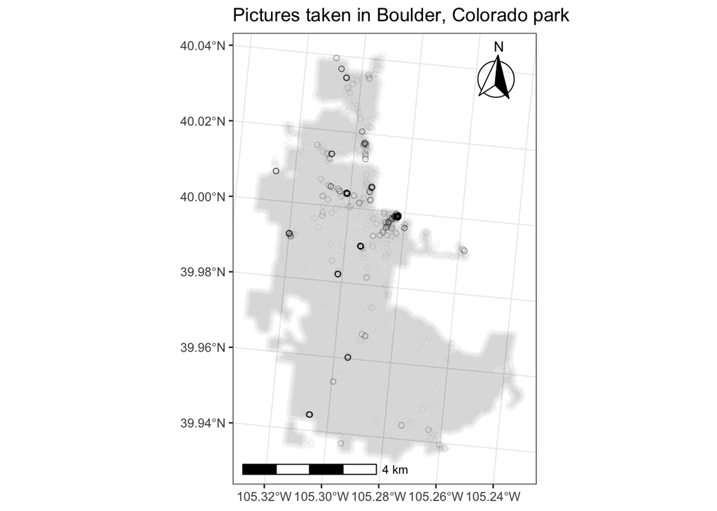

Fig 1. Map of where pictures are being taken in a park in Boulder, CO. The picture points were made less opaque to visualize where most picutures were being taken.

```r
ggplot() +
  annotation_scale(location = "bl", width_hint = 0.5) +
    annotation_north_arrow(location = "tr", which_north = "true",
        style = north_arrow_fancy_orienteering) +
    geom_sf(data = df_boulder,
    fill = NA, alpha = .01, shape = 21) +
  labs(title = "Pictures taken in Boulder, Colorado park") +
    theme_bw()
```

### Investigating where the points are concentrated the most

Below, we visualize where most of the pictures are being taken using a 2D density plot. We can see that most of the pictures taken are concentrated between $105.28^\circ W$ and $105.29^\circ W$ longitudinally, and between $39.99^\circ N$ and $40.00^\circ N$ latitudinally.

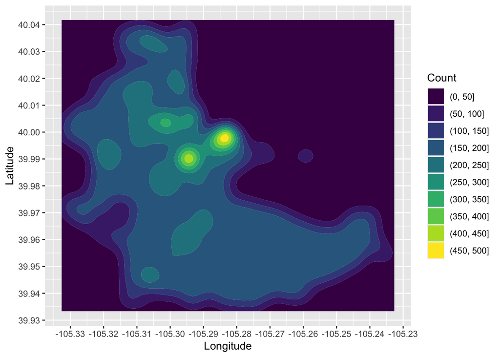

Fig 2. 2D density plot of the pictures being taken in a park in Boulder, CO.

```r
# transform the crs of the dataframe
df_boulder <- st_transform(df_boulder, crs = "+proj=longlat +ellps=WGS84 +datum=WGS84")

# create dummy dataframe
points_pic <- df_boulder

# convert simple features to data frame
points <- as.data.frame(points_pic) #convert to dataframe
points$lon <- unlist(map(points_pic$geometry,1)) #adding lon column
points$lat <- unlist(map(points_pic$geometry,2)) #adding lat column

ggplot(points, aes(x = lon, y = lat)) +
  geom_density2d_filled() +
  scale_x_continuous(breaks = scales::pretty_breaks(n = 10)) +
  scale_y_continuous(breaks = scales::pretty_breaks(n = 10)) +
  labs(x = "Longitude", y = "Latitude", fill = "Count")
```

I reclassifed the points that fall within this boundary as being “high density” (labeled as `high_dens`). The figure below visualizes this classifiation.

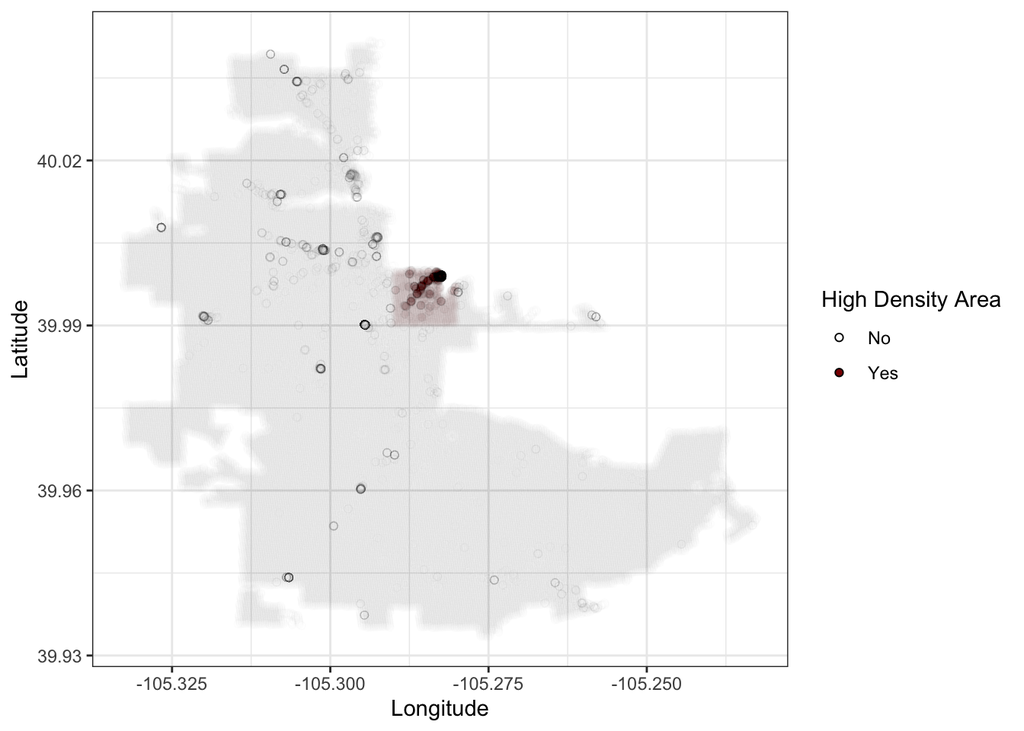

Fig 3. Visualizing the high density area of the park in Boulder, CO.

```r
points %>%
  mutate(high_dens =
           ifelse(
             (lon > -105.29 & lon < -105.28) & (lat > 39.99 & lat < 40.00),
             1,
             0
           )) %>%
  ggplot() +
  geom_point(aes(x = lon, y = lat, fill = as.character(high_dens)), alpha = .01, shape = 21) +
  labs(x = "Longitude", y = "Latitude") +
  scale_fill_manual(values = c("white", "#8b0000"), labels = c("No", "Yes"), name = "High Density Area") +
  guides(fill = guide_legend(override.aes = list(alpha = 1))) +
  theme_bw()
```

I then chose to employ a gradient boosted classification tree model to identify which characteristics are most indicative of a picture being taken at a “high density” area of the park. I used all of the distance variables (e.g., distance to nearest climbing wall) and the elevation variable as predictors of an area being “high density” vs “not high density”. The results of the model may elucidate park-goer behaviors as to why the “high density” area of the park has so many pictures being taken there, and specifically which characteristics of the park in that area may be making so many people take a picture.

```r
# load in library for gradient boosted regression tree model
library(gbm)

# select variables of interst
df_gbm <- points %>%
  mutate(high_dens =
           ifelse(
             (lon > -105.29 & lon < -105.28) & (lat > 39.99 & lat < 40.00),
             1,
             0
           ))  %>%
  select(high_dens, 4:12) %>% # our outcome and the distance variables
  na.omit() %>% as_tibble()

# run model
set.seed(4234); boost_dens <- gbm(high_dens ~ .,
                          data = df_gbm,
                          distribution = 'bernoulli', # our outcome is 1 vs 0
                          cv.folds = 5,
                          shrinkage = 0.01,
                          verbose = FALSE,
                          n.trees = 1000,
                          interaction.depth = 5)

summary(boost_dens, plotit = FALSE) %>%
  as_tibble() %>%
  mutate("Variable Importance" = paste0(round(rel.inf, 1), "%")) %>%
  rename("Variable" = "var") %>%
  select(-2) %>%
  DT::datatable()
```

|  | Variable | Variable Importance |
| --- | --- | --- |
| 1 | PrarDg_Dis | 53.4% |
| 2 | TrailH_Dis | 21.5% |
| 3 | Bike_dis | 8.5% |
| 4 | Trails_dis | 4.8% |
| 5 | Hydro_dis | 4.8% |
| 6 | NatMrk_Dis | 3.1% |
| 7 | Street_dis | 2.6% |
| 8 | Climb_dist | 1.1% |
| 9 | PT_Elev | 0.3% |

The findings from the gradient boosted regression tree model suggest that a picture’s distance from the prairie dog mounds and a picture’s distance from hiking trails are the two most important indicators of a picture being taken in a “high density” area. Let’s examine the individual relationships of each indicator with the outcome.

```r
# get variable names
variables_gbm <- df_gbm %>% select(-1) %>% colnames()

# create variable name crosswalk
var_crosswalk <- tibble(
  variable = variables_gbm,
  nice_var_name = c("Dist. climbing wall", "Dist. hiking trl", "Dist. nat. landmark",
                    "Dist. walking trl", "Dist. biking trl", "Dist. prairie dog",
                    "Elevation", "Dist. lakes, river", "Dist. street")
)

# get order of variables by variable importance from the model
factor_levels <- summary(boost_dens, plotit = FALSE) %>% as_tibble() %>% .$var

# sort the variable crosswalk in order of most important to least important variable
var_crosswalk <- var_crosswalk %>% mutate(variable = factor(variable, levels = factor_levels)) %>% arrange(variable)
```

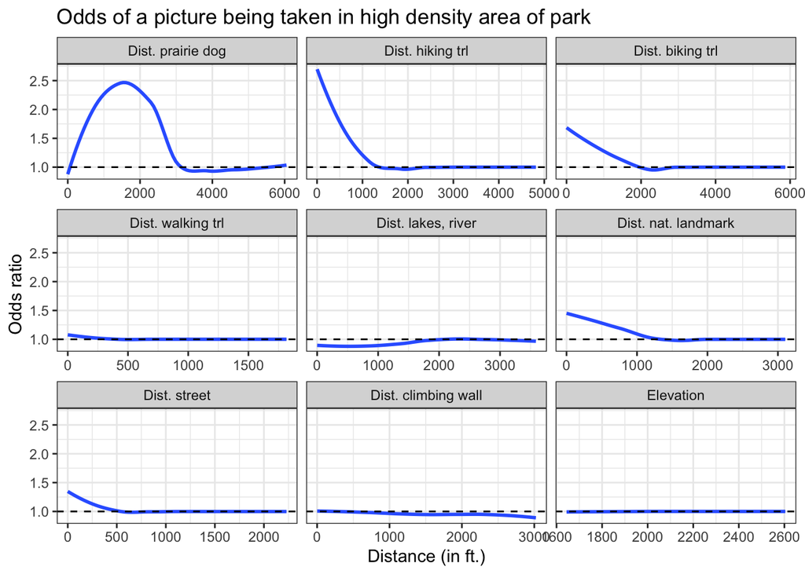

Fig 4. Relationship between each variable from the gradient boosted classification tree model and the odds of a picture being taken in a high density area. Each relationship was normalized to the median and the smoothed relationship is displayed. The null is represented by the dashed line at odds ratio of 1.

```r
# create function to extract odds ratios for each variable
OR_gbm <- function(var) {

  boost_dens %>%
  pdp::partial(plot=FALSE, n.trees = 1000, pred.var = var) %>% # calculate partial dependency
  as_tibble() %>% # convert to tibble
  mutate(variable = var) %>% # rename inputted column to "variable"
  rename("value" = 1) %>% # rename the first column to "value"
  mutate(yhat = 1/(1+exp(-yhat))) %>% # calculate probability
  mutate(yhat = yhat/(1-yhat)) %>% # calculate odds
  mutate(median = median(df_gbm[[var]])) %>% # find median value of variable
  mutate(median_yhat = yhat[which.min(abs(value - median))]) %>% # find OR associated with median of variable
  mutate(OR = yhat/median_yhat) %>% # calculate odds ratio relative to median odds
  select(variable, value, OR) # select the variable name, value, and odds ratio

}

# create single data frame of odds ratios for each variable
OR_df <- NULL
for(i in 1:length(variables_gbm)) {
  temp_df <- OR_gbm(variables_gbm[i])

  OR_df <- rbind(OR_df, temp_df)
}


OR_df %>%
  left_join(var_crosswalk, by = "variable") %>%
  mutate(nice_var_name = factor(nice_var_name, levels = var_crosswalk$nice_var_name)) %>%
  ggplot(aes(x = value, y = OR)) +
  geom_smooth(se = FALSE) +
  geom_hline(yintercept = 1, linetype = "dashed") +
  facet_wrap(~nice_var_name, scales = "free_x") +
  labs(x = "Distance (in ft.)", y = "Odds ratio", title = "Odds of a picture being taken in high density area of park") +
  theme_bw()
```

## Bonus question

*Bonus: Capture a screenshot of the history of your Git commits. Share your strategy for utilizing Git in your workflow.*

Below is an image of my Git commit history. My strategy for utilizing Git into my workflow was rather simplistic for this project. I would save small changes to my code locally, but anytime I had completed a large change (such as finished a question or larger analysis), I would also push a Git commit to ensure that everything was being stored there as well.

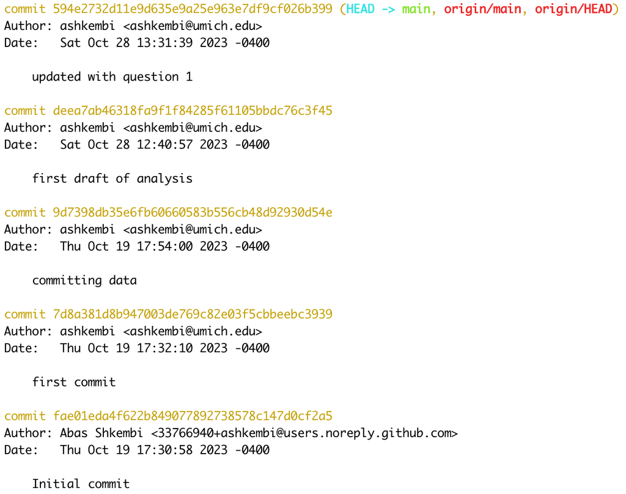

History of Git commits